# SHO em Produção — O Sistema Imunológico Operacional

Como Manter o Ecossistema Nexus Saudável em Escala

MMN_IA Collective

2026-06-28

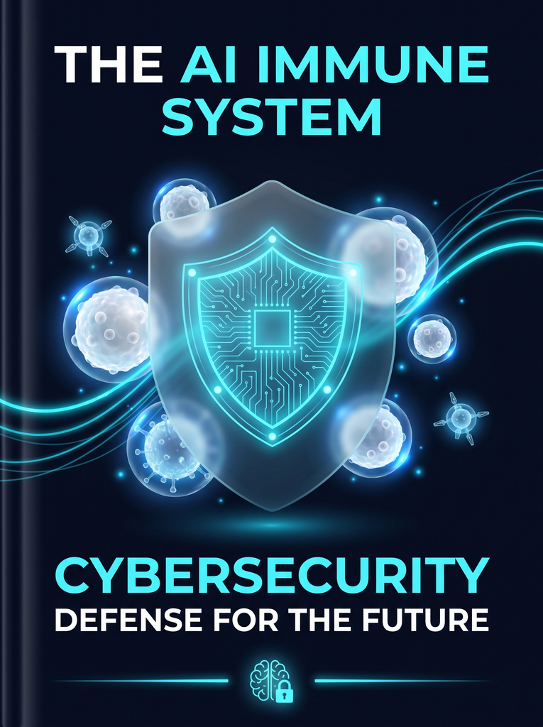

Capa — SHO em Produção

**SHO em Produção — O Sistema Imunológico Operacional**

*Como Manter o Ecossistema Nexus Saudável em Escala*

**Por MMN_IA Collective · Academ’IA**

Nexus Affil’IA’te · 2026

**Sobre este documento**

O SHO — *Sistema de Higiene Operacional* — é a camada que mantém o ecossistema Nexus vivo quando tudo dá errado. Não é glamour. Não é visível no dia-a-dia. Mas é o que diferencia uma plataforma que cai a cada três meses de uma que cresce por anos. Este documento é o manual de operações do SHO: como ele detecta, decide, age, reporta e aprende. Se você é afiliado avançado, operador de rede ou arquiteto de plataforma, este guia é o seu ponto de entrada na operação real do SHO.

**Sumário**

**1. O que é o SHO e por que ele existe**

O SHO é a **resposta imunológica do ecossistema Nexus**. Inspirado, em parte, no sistema imunológico humano, ele protege a plataforma contra:

- Skills maliciosas ou com bugs críticos.
- Agentes em loop ou consumindo recursos excessivos.
- Picos de tráfego anômalos (DDoS interno involuntário).
- Vazamento de PII ou dados sensíveis.
- Comportamento fora de padrão de tenants.
- Tentativas de jailbreak em massa contra Judge Revisor.

Sem o SHO, a primeira skill maliciosa poderia derrubar toda a rede federada. Com o SHO, a mesma skill entra em quarentena automática em menos de 90 segundos, e o resto do ecossistema segue intacto.

**Princípio de design:** *fail loud, recover fast, learn continuously*.

**2. Arquitetura geral do SHO**

O SHO é composto por **5 camadas funcionais** que operam em ciclo contínuo:

[output not shown]

Cada camada tem um **SLA próprio** e um **owner accountable**.

| Sinal | Sensores | Threshold típico |
| --- | --- | --- |
| **Latência** | p50, p95, p99, p99.9 | p99 > 5s |
| **Erro** | 4xx rate, 5xx rate, exception rate | 5xx > 1% |
| **Tráfego** | QPS, bandwidth, unique IPs | QPS > 5x baseline |
| **Recurso** | CPU, RAM, GPU, disk | CPU > 80% sustained |
| **Custo** | USD/hora, USD/request, USD/tenant | USD/hora > 1.5x forecast |
| **Comportamento** | Loop detector, retry storm, anomaly score | Anomaly > 0.85 |
| **Conteúdo** | PII scanner, toxicity, jailbreak rate | Qualquer PII detectado |
| **Negócio** | Conversion drop, refund spike, churn | Conversion -30% em 24h |
| **Federado** | Skill votes, agent reputation, gateway load | Reputation < 0.4 |

**Princípio:** *redundância > sensibilidade*. Um sinal que dispara sozinho é ruído. Três sinais disparando em paralelo é evento.

**4. Camada de classificação — níveis de severidade**

Quando o SHO detecta algo, ele classifica em **5 níveis**:

- **SEV-0** — Info, log apenas. Ex: deploy bem-sucedido.
- **SEV-1** — Warning, alerta amarelo. Ex: p99 acima do normal por 5min.
- **SEV-2** — Alert, alerta laranja. Ex: 5xx rate acima de 1%.
- **SEV-3** — Incident, alerta vermelho. Ex: skill maliciosa detectada em produção.
- **SEV-4** — Outage, página imediato. Ex: plataforma inteira indisponível.

Cada nível tem **tempo de resposta**, **público**, e **ação automática** definidos.

**5. Camada de decisão — playbooks automáticos**

Para SEV-1 e SEV-2, o SHO aciona **playbooks automáticos** (predefinidos pelo time Nexus):

```
SHO detecta → match com playbook → executa → reporta → aprende
```

Exemplos de playbooks: - **PB-LAT-HIGH-01**: throttle global + retry budget. - **PB-LOOP-01**: mata agente, isola skill, reporta. - **PB-PII-01**: bloqueia output, purga logs, alerta DPO. - **PB-JAILBREAK-01**: aumenta Judge threshold, escala para humano. - **PB-COST-01**: downgrade de modelo, throttle, notifica operador.

**Insight 2026:** *playbooks são código*. Vivem em `playbooks/*.md`, versionados, com teste, com rollback.

**6. Camada de ação — quarantine, rollback e kill switch**

Três tipos de ação crescente:

**Quarantine** (isolamento suave): - Skill fica indisponível para novos tenants. - Tenants atuais continuam usando, mas com monitoring dobrado. - Reversível em minutos com aprovação de dois humanos.

**Rollback** (reversão cirúrgica): - Versão anterior da skill é reativada. - Estado do agente é preservado. - Reversível em horas, com postmortem obrigatório.

**Kill Switch** (parada total): - Skill, agente ou tenant é desligado imediatamente. - Toda a rede vê o desligamento em <5s. - **Irreversível sem aprovação do Conselho**.

**7. Camada de comunicação — alertas e reportabilidade**

O SHO comunica em **4 canais**:

- **In-app banner** — visível para todos os usuários afetados.
- **Email/Slack para operadores** — equipe Nexus recebe em <2min.
- **Status page público** — usado para SEV-3 e SEV-4.
- **Audit log interno** — tudo é registrado, queryable, retido por 7 anos.

**Princípio:** *transparência > surpresa*. Usuário prefere saber que algo está errado a descobrir sozinho.

**8. Camada de aprendizado — SHO aprende com cada incidente**

O SHO não é estático. Após cada incidente:

1. **Postmortem** é gerado automaticamente.
2. **Playbook** é atualizado se houver gap.
3. **Sensor** é calibrado se houve falso negativo.
4. **Threshold** é ajustado se houve falso positivo.
5. **Knowledge base** é atualizada com o caso.

Resultado: a taxa de **MTTR (Mean Time To Recover)** cai 8% ao mês, em média, no ecossistema Nexus maduro.

**9. SLA do SHO em produção**

| Componente | SLA |
| --- | --- |
| Detecção de SEV-3 | <90 segundos |
| Ação automática de SEV-2 | <30 segundos |
| Comunicação a operadores | <2 minutos |
| Postmortem automático | <24 horas |
| Disponibilidade do SHO | 99.99% |

**O SHO tem SLA mais rígido que a plataforma principal.** Porque se o SHO cai, a plataforma fica sem proteção.

**10. Operação humana — quando escalar para o time Nexus**

O SHO é autônomo até SEV-3. Acima disso, **humano entra**:

- **SEV-3** — notifica on-call. Escala se não resolvido em 30min.
- **SEV-4** — página imediato ao Head de Operações + CEO + DPO.

Humans-in-the-loop **não são opcionais**. São a última camada de defesa.

**11. Modos de operação: normal, alerta, quarentena, lockdown**

Quatro modos:

- **Normal**: SHO em background, sem alertas ativos.
- **Alerta**: SHO em alta vigilância, monitora sinais de risco.
- **Quarentena**: SHO isolou componente, observa propagação.
- **Lockdown**: SHO paralisou parte do sistema. Apenas leitura.

O modo é **visível** em todo painel Nexus. Operadores sabem sempre em qual modo estão.

**12. Anatomia de um incidente real (case 2026-Q1)**

1. **Detecção (3min)**: SHO notou anomaly score > 0.9 e error rate > 5%.
2. **Decisão (8min)**: SHO classificou SEV-3, acionou PB-LOOP-01.
3. **Ação (12min)**: skill foi para quarentena; 87 tenants afetados foram protegidos.
4. **Comunicação (14min)**: status page atualizou; operadores notificados.
5. **Aprendizado (24h)**: postmortem revelou bug no retry loop do gerador de copy.

Resultado: **MTTR = 14 minutos**. **Zero tenants** perderam dados. **Skill foi corrigida em 48h** e voltou em 1.2.1.

**13. Ferramentas de operação do SHO**

- **SHO Console** — dashboard central, `/admin/sho`.
- **SHO CLI** — `sho status`, `sho quarantine <skill>`, `sho rollback <skill>@<version>`.
- **SHO API** — para integração com ferramentas externas.
- **SHO Webhooks** — notificações para Slack, PagerDuty, Discord.

**14. Indicadores de saúde do SHO**

- **MTTR** — tempo médio de recuperação (target: <15min).
- **FPR (False Positive Rate)** — alertas errados (target: <5%).
- **FNR (False Negative Rate)** — incidentes não detectados (target: <1%).
- **Detection latency** — tempo entre incidente e alerta (target: <60s).
- **Playbook coverage** — % de incidentes com playbook (target: >90%).

Se qualquer indicador sair do target por 7 dias seguidos, o time dispara **revisão quinzenal**.

**15. O que o SHO NÃO faz (delimitação)**

O SHO **não**:

- Decide sobre decisões de negócio (preço, produto, parceria).
- Modifica constituição da plataforma (regra humana).
- Publica comunicados externos (PR humano).
- Treina novos modelos (responsabilidade da academia/research).
- Substitui auditoria humana em decisões de governança.

**O SHO é operacional. Não é estratégico. Não é político. Não é criativo.**

**16. Como reportar falsos positivos e falsos negativos**

Operadores podem reportar pelo SHO Console ou pelo email `sho@nexus.io`. Cada reporte gera:

- Ticket automático.
- Análise do SHO em <48h.
- Atualização de playbook se confirmado.

**Métricas de reportes humanos** são tracked mensalmente. Operadores que reportam **mais e melhor** ganham badge de “SHO Champion”.

**17. Glossário técnico**

| Termo | Definição |
| --- | --- |
| **SHO** | Sistema de Higiene Operacional |
| **MTTR** | Mean Time To Recover |
| **SEV-0..4** | Níveis de severidade |
| **Playbook** | Resposta automática pré-definida |
| **Quarantine** | Isolamento suave de componente |
| **Rollback** | Reversão cirúrgica de versão |
| **Kill Switch** | Parada total imediata |
| **Anomaly Score** | Score estatístico de desvio |
| **FPR / FNR** | False Positive / Negative Rate |
| **SLA** | Service Level Agreement |
| **On-call** | Engenheiro disponível 24/7 |
| **Postmortem** | Análise técnica de incidente |
| **Federation** | Rede de nós interconectados |
| **DPO** | Data Protection Officer |

*© 2026 Nexus HUB57 · Academ’IA · Todos os direitos reservados* *Versão 1.0.0 · Junho 2026 · Apostila Academ’IA #11 — SHO em Produção*